# U.S. Education-Energy Poverty Nexus

Desik Somasundaram

11/26/2021

## Introduction

**Premise:** Energy poverty is one of the significant challenges for developing countries of the world with more than a billion people around the world lacking access to simple technologies such as lamps and appliances. The idea that the lack of access to lighting at night or heating/cooling during thermal comfort could impact children and their ability to perform well in school seems apparent. Several studies have concluded households with a low level of educational attainment have more limited access to electricity and other forms of clean energy (Apergis, Polemis, and Soursou 2021). It’s evident that there’s potential for a vicious cycle where energy poverty is hindering education which in turn decreasing their ability to escape it; ultimate depriving people of a higher quality life.

**Question:** Do these relationships between energy poverty and education hold true in the United States (the developed country context, based on GDP)?

**Motivation:** There is a lack of research connecting education and energy poverty in the US. Though electricity access is prevalent in the U.S., anticipated increased variability in climate could make the U.S. particularly vulnerable. The disparities in energy equity considering income and race across the US are not recognized as a problem at the federal level, therefore limiting the response to this issue unlike the gradual and coordinated response in countries such as the UK (Bednar and Reames 2020). The goal of this project is to encourage more research through the education-energy poverty nexus lens.

## Datasets Used

The analysis was conducted on the county level in the US due to the increased sampling power and available data resolution for parameters in question.

**Educational Attainment data** available on the county-level from the USDA Economic Research Service, the most recent data is available for 2015 to 2019 (Link: https://data.ers.usda.gov/reports.aspx?ID=17829 )

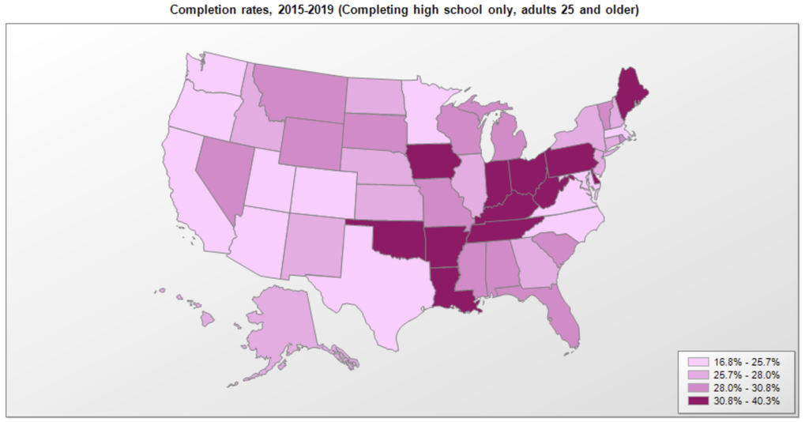

**Comprehensive County Indicators data** from County Health Rankings which compiles data from several data sources. The final analysis used the *math and reading score indicators* from this dataset that are modelled by Stanford Education Data Archive program based on EDFacts and state sources to achieve comparability across the country. Although the dataset is labelled as 2021 data, the testing score is actually based on 2018. The math and reading scores are presented as average grade level performance for 3rd graders. The scores generally range from 1 to 4. The expected value is 3 indicating that 3rd graders are performing at a 3rd grade level. A score of 3.5 would they are perform 0.5 a grade level higher than expected. (Link: https://www.countyhealthrankings.org/explore-health-rankings/rankings-data-documentation)

**Low-Income Energy Affordability data** available on county-level from the Department of Energy based on modelling done using the 2016 5-year American Community Survey (ACS5) (Link: https://www.energy.gov/eere/slsc/low-income-energy-affordability-data-lead-tool)

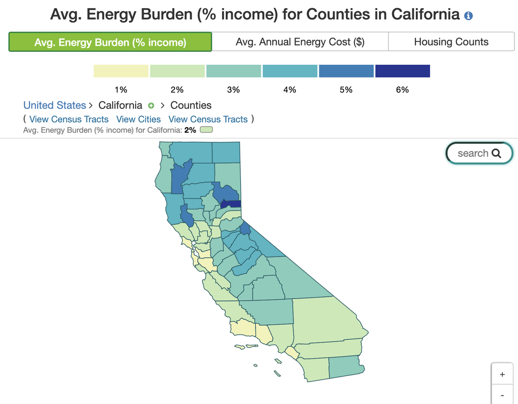

**Limitations of the the datasets used**:

The LEAD energy affordability estimates are centered around housing energy costs. While this is important, an entire dimension of inequity due to energy poverty and mobility is missed out on due to the lack of information on transportation sector.

With county-level resolution in US being so challenging to achieve, it’s important to note that there are several processes of modelling and estimations incorporated into the available datasets for the education data and LEAD tool that must be considered and noted. Biases could arise due to response bias and attrition for the surveys such as the American Community Survey (ACS) that are heavily relied on.

Nevertheless, this analysis will use the best available data to my knowledge for reasonably overlapping time periods.

## Analysis Plan

There will be two stages to the analysis.

### Part 1

First will be exploring whether there is a correlation between educational attainment and energy burden.

**How does educational attainment affect energy burden?**

The Apergis, Polemis, and Soursou 2021 paper concluded that across several energy poverty and education studies in developing countries that “households with a low level of educational attainment, have restricted access to clean energy forms, such as electricity”. In the developed country context, we will test if a similar relationship exists between educational attainment and energy burden. The assumption is that **energy burden** is a representative measure of access instead of the binary “access/no access” scenario in developing countries.

$$\text{energy burden}_i = \beta_0 + \beta_1 \text{educational attainment}_i + \epsilon_i$$
**Energy burden will be represent by the average energy burden (% Income)** from the LEAD Energy Affordability data **Educational attainment will be represented by the % of adults with a HS diploma or less** from USDA Economic Research Service data

### Part 2

Next we will be exploring whether there is a correlation between energy burden and educational outcomes(measured by standardized math and reading scores). The idea is that examining a short-term education measure such as standardized test scores will reflect the effects of energy burden as surveyed and modeled in recent data.

**Does energy burden affect a student’s ability to do well in school?**

The assumption is that 3rd grader **english and math standardized test scores** are a representative measure of doing well in school.

With the energy affordability data mainly reflecting household building energy needs, it is expected that heating and cooling dominates energy spending. US Energy Information Administration estimates that more that half of household energy spending is spent on heating and cooling. The lack of thermal comfort has shown to increase the amount of mistakes by even adults. The Institute of Education Sciences has compiled literature on the optimal learning temperature based on thermal comfort (https://ies.ed.gov/ncee/edlabs/regions/west/Ask/Details/64).

The rationale is that although most families in America have access to electricity and basic technologies such as lighting and temperature regulation, they may be unable to take full advantage of them due to the energy burden.

$$\text{standardized test scores-READING}_i = \beta_0 + \beta_1 \text{energy burden}_i + \epsilon_i$$
$$\text{standardized test scores-MATH}_i = \beta_0 + \beta_1 \text{energy burden}_i + \epsilon_i$$
**Standardized test scores will be represented by the math and reading scores presented as average grade level performance for 3rd graders** from Stanford Education Data Archive data accessed through County Health Rankings **Energy burden will be represent by the average energy burden (% Income)** from the LEAD Energy Affordability data

## Results

**Does educational attainment affect energy burden?**

|  | Estimate | Std. Error | t value | Pr(>\|t\|) |
| --- | --- | --- | --- | --- |
| (Intercept) | 1.111 | 0.096 | 11.553 | 0 |
| pct_hs_or_less | 0.062 | 0.002 | 31.206 | 0 |

**Answer: Since $p-value is < 0.001$ we reject the null that educational attainment(% with HS diploma or less) has an effect of 0 on Average Energy Burden(% Income).** We can say there is a **statistically significant correlation (at the 0.1% significance level).**

The $\beta_1$ indicates that there is **0.062 increase in average energy burden as % Income for every percent point increase in % with HS diploma or less** in a given a county.

Although the estimated coefficient is positive, it is truly reflecting a negative correlation between educational attainment and energy burden. Since the educational attainment variable used is % with a high school diploma or less, an increase in this variable indicates less education attained. Therefore, with less education attained, there is an increase in energy burden.

**Does energy burden affect reading scores (among 3rd graders)?**

|  | Estimate | Std. Error | t value | Pr(>\|t\|) |
| --- | --- | --- | --- | --- |
| (Intercept) | 3.243 | 0.016 | 200.764 | 0 |
| avg_energy_burden_percent_income | -0.059 | 0.004 | -15.377 | 0 |

**Does energy burden affect math scores (among 3rd graders)?**

|  | Estimate | Std. Error | t value | Pr(>\|t\|) |
| --- | --- | --- | --- | --- |
| (Intercept) | 3.233 | 0.019 | 170.446 | 0 |
| avg_energy_burden_percent_income | -0.063 | 0.005 | -14.016 | 0 |

**Answer: Since $p-value is < 0.001$ we reject the null that there is that Average Energy Burden(% Income) has an effect of 0 on standardized test scores.** We can say there is a **statistically significant correlation (at the 0.1% significance level).**

The $\beta_1$ indicates that there is **0.06 decrease in average grade level in reading and math scores for every percent point increase in average energy burden as % Income** in a given a county.

## Conclusions and Next steps

Starting points could be:

1. Are there any potential omitted variable biases?
2. Is energy poverty able to be detached from the effects of poverty and income levels as a whole?
3. What variables could enable the existing models to be developed into predictive models?

Answering these questions could help gather the needed attention on energy poverty in the US and how a targeted approach could be used to address the inequities.

## References

Apergis, Nicholas, Michael Polemis, and Simeoni-Eleni Soursou. 2021. “Energy Poverty and Education: Fresh Evidence from a Panel of Developing Countries.” Energy Economics, July, 105430. https://doi.org/10.1016/j.eneco.2021.105430. Bednar, Dominic J., and Tony G. Reames. 2020. “Recognition of and Response to Energy Poverty in the United States.” Nature Energy 5 (6): 432–39. https://doi.org/10.1038/s41560-020-0582-0. “County Health Rankings 2021: Codebook for Analytic Datasets.” 2018, 5. “Does Temperature Impact Student Performance? | Association for Learning Environments.” n.d. Accessed November 29, 2021a. https://healthyschools.cefpi.org/temperature.html. “———.” n.d. Accessed November 29, 2021b. https://healthyschools.cefpi.org/temperature.html. “Math Scores*.” n.d. County Health Rankings & Roadmaps. Accessed November 29, 2021. https://www.countyhealthrankings.org/explore-health-rankings/measures-data-sources/county-health-rankings-model/health-factors/social-and-economic-factors/education/math-scores. “Reading Scores*.” n.d. County Health Rankings & Roadmaps. Accessed November 29, 2021. https://www.countyhealthrankings.org/explore-health-rankings/measures-data-sources/county-health-rankings-model/health-factors/social-and-economic-factors/education/reading-scores. University, © Stanford, Stanford, and California 94305. n.d. “Stanford Education Data Archive (SEDA).” Accessed November 29, 2021. https://purl.stanford.edu/db586ns4974. “Use of Energy in Homes - U.S. Energy Information Administration (EIA).” n.d. Accessed November 29, 2021. https://www.eia.gov/energyexplained/use-of-energy/homes.php.